# Regression Calibration Demo

Donna Spiegelman (Yale School of Public Health)

Molin Wang (Harvard T.H. Chan School of Public Health)

Jingyu Cui (Yale School of Public Health)

In this demo, we mainly focus on correcting for measurement error in covariates when the outcome is binary.

## 1. Two Methods for Regression Calibration if Validation Study Available

- Deattenuation Factor Method (RC-DF): regCalibDF
- SubstitutionMethod (RC-Sub): regCalibSub

### 1.1 Introduction to Dataset

The data is from a study on [Dietary Fat Intake and the Risk of Breast Cancer](https://www.nejm.org/doi/full/10.1056/NEJM198701013160105)

- Main Study: 89,538 women returned a food frequency questionnaire (FFQ) in 1980 in the Nurses’ Health Study (NHS).
  - Dietary intake was measured through a 61-item FFQ asking about the usual frequency of intake of the most common foods during the past year.
  - Breast cancer incidence over the first 4 years of the follow-up was ascertained by self-report and validated through medical records review.
- Validation Study: 173 women from the MS.
  - The VS participants completed 4 one-week diet records over a one-year period in 1980-1981.

#### Variable Dictionary

- **fq***: Questionnaire-based error-prone surrogates.
- **dr***: diet-record-based (more accurate) dietary intakes derived from the 4 one-week diet records in the validation study.
- Variables contained in both **main and validation data**:
  - **fq**cal: Daily total caloric intake obtained from the dietary questionnaire (kcal/day).
  - **fq**calinc: Daily total caloric intake from the dietary questionnaire, expressed in units of 800 kcal/day.
  - **fq**tfat: Daily total fat intake obtained from the dietary questionnaire (g/day).
  - **fq**tfatinc: Daily total fat intake from the dietary questionnaire, expressed in units of 10 g/day.
  - **fq**alc: Daily alcohol intake obtained from the dietary questionnaire (g/day).
  - **fq**alcinc: Daily alcohol intake from the dietary questionnaire, expressed in units of 12 g/day.
  - age: Age in years
  - agec: Discretized age: <40, [40, 45), [45, 55), [50,55),>=50
- Variables contained in **main data**:
  - case: Binary outcome variable, if the breast cancer occurred during the four year follow-up
- Contained in **validation data**:
  - **dr**cal: Daily total caloric intake from the diet record (kcal/day).
  - **dr**calinc: Daily total caloric intake from the diet record, expressed in units of 800 kcal/day.
  - **dr**tfat: Daily total fat intake from the diet record (g/day).
  - **dr**tfatinc: Daily total fat intake from the diet record, expressed in units of 10 g/day.
  - **dr**alc: Daily alcohol intake from the diet record (g/day).
  - **dr**alcinc: Daily alcohol intake from the diet record, expressed in units of 12 g/day.

### 1.2 Importing Data

Data Use Notice: The dataset provided here is for educational use in this short course only and can not be copied, redistributed, or used for any other purpose.

```r
# read in the main study data
main_data <- read.csv("main_data_external.csv", row.names = 1)
main_data$agec<-factor(main_data$agec, levels = c("<40", "40~45", "45~50", "50~55", ">=50"))

# read in the validation study data
valid_data <- read.csv("valid_data_external.csv", row.names = 1)
valid_data$agec <- factor(valid_data$agec, levels = c("<40", "40~45", "45~50", "50~55", ">=50"))

# show the first 5 rows of the data
head(main_data)
```

```
##       id fqcal fqcalinc fqtfat fqtfatinc  fqalc  fqalcinc      age  agec case
## 1 100008  1661  2.07625     88       8.8  8.413 0.7010833 48.75000 45~50    0
## 2 100013  1573  1.96625     65       6.5  0.000 0.0000000 37.83333   <40    0
## 3 100015  1071  1.33875     44       4.4  7.549 0.6290833 45.66667 45~50    0
## 4 100017  1000  1.25000     52       5.2 29.114 2.4261667 48.08333 45~50    0
## 5 100018  2013  2.51625     79       7.9 11.137 0.9280833 54.91667 50~55    0
## 6 100022  3073  3.84125    133      13.3  0.000 0.0000000 52.50000 50~55    0
```

```r
head(valid_data)
```

```
##       id  fqcal fqcalinc fqtfat fqtfatinc fqalc  fqalcinc drcal drcalinc drtfat
## 1 100396 1242.2 1.552750   53.8      5.38  1.68 0.1400000  1807  2.25875  81.15
## 2 100566  907.0 1.133750   36.6      3.66  0.00 0.0000000  1418  1.77250  53.28
## 3 107633  786.0 0.982500   47.2      4.72 15.10 1.2583333  1889  2.36125  83.48
## 4 107737 1392.5 1.740625   55.3      5.53  7.49 0.6241667  1426  1.78250  49.65
## 5 107744 1259.8 1.574750   71.0      7.10 12.84 1.0700000  1253  1.56625  55.18
## 6 107813  987.1 1.233875   41.1      4.11  0.00 0.0000000  1699  2.12375  73.83
##   drtfatinc dralc   dralcinc age  agec
## 1     8.115  8.26 0.68833333  39   <40
## 2     5.328  0.83 0.06916667  49 45~50
## 3     8.348 20.13 1.67750000  43 40~45
## 4     4.965 11.16 0.93000000  51 50~55
## 5     5.518  7.18 0.59833333  53 50~55
## 6     7.383  1.76 0.14666667  54 50~55
```

### 1.3 Data Exploration

Comparing the mean and standard deviation of questionnaire-based measures and diet record-based record measures in the validation study.

```r
summary_table1 <- matrix(NA, nrow = 3, ncol = 4)
summary_table1[1,] <- c(mean(valid_data$fqcal), sd(valid_data$fqcal), mean(valid_data$drcal), sd(valid_data$drcal))
summary_table1[2,] <- c(mean(valid_data$fqtfat), sd(valid_data$fqtfat), mean(valid_data$drtfat), sd(valid_data$drtfat))
summary_table1[3,] <- c(mean(valid_data$fqalc), sd(valid_data$fqalc), mean(valid_data$dralc), sd(valid_data$dralc))
row.names(summary_table1) <- c("Total calories", "Total fat", "Alcohol intakes")
colnames(summary_table1) <- c("Mean (fq)", "SD (fq)", "Mean (dr)", "SD (dr)")
round(summary_table1, 2)
```

```
##                 Mean (fq) SD (fq) Mean (dr) SD (dr)
## Total calories    1371.73  482.05   1619.87  323.41
## Total fat           56.08   21.97     68.62   16.29
## Alcohol intakes      8.95   12.25      8.96    9.66
```

Correlation between questionnaire-based measure and diet record-based record measures in the validation study.

```r
Summary_table2 <- cor(valid_data[, c(2,4,6)], valid_data[,c(8,10,12)])
Summary_table2
```

```
##            drcal    drtfat       dralc
## fqcal  0.3559695 0.2987738 -0.06172778
## fqtfat 0.3150312 0.3696641  0.01036997
## fqalc  0.1974423 0.1308419  0.84988383
```

The measures of total calories, total fat, and alcohol intakes from questionnaire and diet records are correlated.

```r
cor(valid_data[, c(2,4,6)])
```

```
##                fqcal     fqtfat         fqalc
## fqcal   1.0000000000 0.88621802 -0.0005010716
## fqtfat  0.8862180190 1.00000000  0.0760384810
## fqalc  -0.0005010716 0.07603848  1.0000000000
```

```r
cor(valid_data[,c(8,10,12)])
```

```
##            drcal     drtfat      dralc
## drcal  1.0000000 0.88453882 0.20152169
## drtfat 0.8845388 1.00000000 0.09584735
## dralc  0.2015217 0.09584735 1.00000000
```

**Outcome model**:
$$\begin{aligned}
&logit(\text{Probability of breast cancer occured})\\
&\sim\text{fat }(10g/day)\;+\;\text{calories
}(800kcal/day)\;+\;\text{alcohol }(12g/day)\\
&\quad +\; \mathbf{1}\!\left(\text{age}\in[40,45)\right)
+\mathbf{1}\!\left(\text{age}\in[45,50)\right)
+\mathbf{1}\!\left(\text{age}\in[50,55)\right)
+\mathbf{1}\!\left(\text{age}\ge 50\right).
\end{aligned}$$

(age $<40$ is the reference category for age.)

### 1.4 Naive Analysis

```r
# Logistic regression in the MS
uncorrected <- glm(case ~ fqtfatinc + fqcalinc + fqalcinc + agec, data=main_data, family=binomial(link = "logit"))
# calculating the OR and CI
uncorrected_results <- exp(cbind(OR = coef(uncorrected), confint(uncorrected)))
uncorrected_results
```

```
##                     OR       2.5 %     97.5 %
## (Intercept) 0.00380417 0.002696806 0.00531978
## fqtfatinc   0.97883434 0.924601002 1.03613092
## fqcalinc    1.00207749 0.770922385 1.29395543
## fqalcinc    1.14859818 1.064814610 1.23386158
## agec40~45   1.41923883 1.041903968 1.94118652
## agec45~50   2.28648649 1.731062686 3.04929876
## agec50~55   2.25490565 1.702950573 3.01337360
## agec>=50    2.66079494 2.004133696 3.56370240
```

```r
summary(uncorrected)
```

```
##
## Call:
## glm(formula = case ~ fqtfatinc + fqcalinc + fqalcinc + agec,
##     family = binomial(link = "logit"), data = main_data)
##
## Coefficients:
##              Estimate Std. Error z value Pr(>|z|)
## (Intercept) -5.571658   0.173197 -32.169  < 2e-16 ***
## fqtfatinc   -0.021393   0.029066  -0.736 0.461721
## fqcalinc     0.002075   0.132144   0.016 0.987470
## fqalcinc     0.138542   0.037551   3.689 0.000225 ***
## agec40~45    0.350121   0.158422   2.210 0.027102 *
## agec45~50    0.827016   0.144188   5.736 9.71e-09 ***
## agec50~55    0.813108   0.145337   5.595 2.21e-08 ***
## agec>=50     0.978625   0.146580   6.676 2.45e-11 ***
## ---
## Signif. codes:  0 '***' 0.001 '**' 0.01 '*' 0.05 '.' 0.1 ' ' 1
##
## (Dispersion parameter for binomial family taken to be 1)
##
##     Null deviance: 7212.6  on 89537  degrees of freedom
## Residual deviance: 7124.9  on 89530  degrees of freedom
## AIC: 7140.9
##
## Number of Fisher Scoring iterations: 8
```

### 1.5 Regression Calibration – Deattenuation Factor Method (RC-DF)

#### Assumptions

1. Surrogacy: P(Y=1|X,Z,V)=P(Y=1|X,V).
2. Transportability.
3. Logistic-linearity of the outcome model.

$$\begin{aligned}
&logit(\text{Probability of breast cancer occured})\\
&\sim\text{fat }(10g/day)\;+\;\text{calories
}(800kcal/day)\;+\;\text{alcohol }(12g/day)\\
&\quad +\; \mathbf{1}\!\left(\text{age}\in[40,45)\right)
+\mathbf{1}\!\left(\text{age}\in[45,50)\right)
+\mathbf{1}\!\left(\text{age}\in[50,55)\right)
+\mathbf{1}\!\left(\text{age}\ge 50\right).
\end{aligned}$$

4. Linearity in the measurement error model

$$\begin{aligned}
\mathrm{DR\_Alcohol}(12g/day)
&\sim\mathrm{FFQ\_Alcohol}(12g/day)
+ \mathrm{FFQ\_Total\_Fat}(10g/day)
+ \mathrm{FFQ\_Calories}(800kcal/day) \\
&\quad + \mathbf{1}\!\left(\mathrm{Age}\in[40,45)\right)
+ \mathbf{1}\!\left(\mathrm{Age}\in[45,50)\right)
+ \mathbf{1}\!\left(\mathrm{Age}\in[50,55)\right)
+ \mathbf{1}\!\left(\mathrm{Age}\ge 50\right), \\[6pt]
\mathrm{DR\_Total\_Fat}(10g/day)
&\sim \mathrm{FFQ\_Total\_Fat}(10g/day)
+ \mathrm{FFQ\_Alcohol}(12g/day)
+ \mathrm{FFQ\_Calories}(800kcal/day) \\
&\quad + \mathbf{1}\!\left(\mathrm{Age}\in[40,45)\right)
+ \mathbf{1}\!\left(\mathrm{Age}\in[45,50)\right)
+ \mathbf{1}\!\left(\mathrm{Age}\in[50,55)\right)
+ \mathbf{1}\!\left(\mathrm{Age}\ge 50\right), \\[6pt]
\mathrm{DR\_Calories}(800kcal/day)
&\sim \mathrm{FFQ\_Calories}(800kcal/day)
+ \mathrm{FFQ\_Alcohol}(12g/day)
+ \mathrm{FFQ\_Total\_Fat}(10g/day) \\
&\quad + \mathbf{1}\!\left(\mathrm{Age}\in[40,45)\right)
+ \mathbf{1}\!\left(\mathrm{Age}\in[45,50)\right)
+ \mathbf{1}\!\left(\mathrm{Age}\in[50,55)\right)
+ \mathbf{1}\!\left(\mathrm{Age}\ge 50\right).
\end{aligned}$$

5. For logistic regression, at least one of the following two conditions should hold:
   - Small measurement error variance.
   - Rare disease outcome plus normally distributed homoscedastic error: 4-year cumulative incidence of breast cancer is 0.7%.

#### Running code

Install R package: RegCalib

Click “No” when asking if you want to restart R before install.

```r
install.packages("devtools")
devtools::install_github("JingyuCui639/RegCalib")
```

```r
library(RegCalib)
```

Check the [GitHub repository](https://github.com/JingyuCui639/RegCalib) for more details about the R package `RegCalib`.

```r
rcdf <- RegCalibDF(supplyEstimates = FALSE, # let the function run the outcome model internally
ms = main_data,             # main study data.frame
vs = valid_data,            # external validation data.frame
sur = c("fqtfatinc","fqcalinc","fqalcinc"), # mismeasured surrogate variable name(s) in ms
exp = c("drtfatinc","drcalinc","dralcinc"), # true exposure variable name(s) in vs (same order as sur)
covCalib = c("agec"),       # covariates in BOTH calibration and outcome model (or NULL if none)
covOutcomePlus = NULL,#specifies the covariates (unrelated to exposure) included in the outcome model in addition to the covariates included in the calibration model as given by "covCalib".
outcome = "case",           # outcome variable name (must be in ms)
method = "glm",             # methods for outcome modeling
family = binomial,          # family parameter being passed to glm
link = "logit",             # link function being passed to glm
external = TRUE,            # Indicates whether `vs` is an external validation set.
pointEstimates = NA,
vcovEstimates = NA
)
```

```r
rcdf
```

```
## $correctedCoefTable
##               Estimate Std. Error     Z Value     Pr(>|Z|) lower 95%CI
## drtfatinc -0.068729320 0.08270995 -0.83096801 4.059917e-01 -0.23083784
## drcalinc   0.006928094 0.40899379  0.01693936 9.864850e-01 -0.79468501
## dralcinc   0.218024570 0.07353743  2.96481097 3.028690e-03  0.07389386
## agec40~45  0.354715383 0.16187846  2.19124516 2.843406e-02  0.03743944
## agec45~50  0.761049484 0.15886396  4.79057347 1.663053e-06  0.44968184
## agec50~55  0.758642325 0.15744780  4.81837361 1.447332e-06  0.45005031
## agec>=50   0.930993372 0.15775705  5.90143733 3.603483e-09  0.62179523
##           upper 95%CI
## drtfatinc   0.0933792
## drcalinc    0.8085412
## dralcinc    0.3621553
## agec40~45   0.6719913
## agec45~50   1.0724171
## agec50~55   1.0672343
## agec>=50    1.2401915
##
## $correctedVCOV
##               drtfatinc     drcalinc      dralcinc     agec40~45    agec45~50
## drtfatinc  0.0068409352 -0.024759403  0.0023929387  0.0009147159  0.002232790
## drcalinc  -0.0247594027  0.167275921 -0.0189334178 -0.0041274281  0.006761474
## dralcinc   0.0023929387 -0.018933418  0.0054077531  0.0002707423 -0.001567489
## agec40~45  0.0009147159 -0.004127428  0.0002707423  0.0262046346  0.014715934
## agec45~50  0.0022327898  0.006761474 -0.0015674886  0.0147159336  0.025237759
## agec50~55  0.0036036333 -0.005882769 -0.0001248312  0.0149899096  0.017165914
## agec>=50   0.0037520491 -0.008570755  0.0002153392  0.0150311353  0.016796463
##               agec50~55      agec>=50
## drtfatinc  0.0036036333  0.0037520491
## drcalinc  -0.0058827686 -0.0085707547
## dralcinc  -0.0001248312  0.0002153392
## agec40~45  0.0149899096  0.0150311353
## agec45~50  0.0171659136  0.0167964631
## agec50~55  0.0247898098  0.0170680796
## agec>=50   0.0170680796  0.0248872884
##
## $standardCoefTable
##               Estimate Std. Error     z value     Pr(>|z|)
## fqtfatinc -0.021392868 0.02906574 -0.73601658 4.617206e-01
## fqcalinc   0.002075332 0.13214415  0.01570506 9.874697e-01
```

[output cut: 36 more lines]

```
## drtfatinc  2.183066e+00  4.933365e-01 8.207839e-03 -6.872743e-19 -4.754891e-18
## drcalinc   4.933365e-01  1.364640e-01 1.950379e-02 -5.989957e-19 -1.187895e-18
## dralcinc   8.207839e-03  1.950379e-02 1.848283e-01  1.135229e-19  7.216745e-19
## agec40~45 -6.872743e-19 -5.989957e-19 1.135229e-19  5.957995e-31  1.031805e-30
## agec45~50 -4.754891e-18 -1.187895e-18 7.216745e-19  1.031805e-30  1.941621e-30
## agec50~55 -3.771147e-19  4.301220e-20 9.198886e-19  4.392695e-31  7.433341e-31
## agec>=50  -1.141978e-18 -2.499690e-19 1.489831e-19  1.806017e-31  3.503511e-31
##               agec50~55      agec>=50
## drtfatinc -3.771147e-19 -1.141978e-18
## drcalinc   4.301220e-20 -2.499690e-19
## dralcinc   9.198886e-19  1.489831e-19
## agec40~45  4.392695e-31  1.806017e-31
## agec45~50  7.433341e-31  3.503511e-31
## agec50~55  3.507419e-31  1.160834e-31
## agec>=50   1.160834e-31  1.009527e-31
```

```r
# Corrected regression coefficients (exponentiated)
corrected_RC_DF <- exp(cbind(OR = rcdf$correctedCoefTable[,1],
'2.5 %' = rcdf$correctedCoefTable[,5],
'97.5 %' = rcdf$correctedCoefTable[,6]))
corrected_RC_DF
```

```
##                  OR     2.5 %   97.5 %
## drtfatinc 0.9335793 0.7938682 1.097878
## drcalinc  1.0069521 0.4517235 2.244631
## dralcinc  1.2436176 1.0766925 1.436422
## agec40~45 1.4257748 1.0381491 1.958133
## agec45~50 2.1405215 1.5678133 2.922435
## agec50~55 2.1353751 1.5683911 2.907328
## agec>=50  2.5370281 1.8622682 3.456275
```

```r
# compare results from naive and RC-DF methods
cbind(uncorrected_results[-1,], corrected_RC_DF)
```

```
##                  OR     2.5 %   97.5 %        OR     2.5 %   97.5 %
## fqtfatinc 0.9788343 0.9246010 1.036131 0.9335793 0.7938682 1.097878
## fqcalinc  1.0020775 0.7709224 1.293955 1.0069521 0.4517235 2.244631
## fqalcinc  1.1485982 1.0648146 1.233862 1.2436176 1.0766925 1.436422
## agec40~45 1.4192388 1.0419040 1.941187 1.4257748 1.0381491 1.958133
## agec45~50 2.2864865 1.7310627 3.049299 2.1405215 1.5678133 2.922435
## agec50~55 2.2549056 1.7029506 3.013374 2.1353751 1.5683911 2.907328
## agec>=50  2.6607949 2.0041337 3.563702 2.5370281 1.8622682 3.456275
```

### 1.6 Regression Calibration – Substitution Method (RC-Sub)

#### Assumptions

1. Surrogacy
2. Transportability
3. Logistic-linearity of the outcome model
   $$\begin{aligned}
   &logit(\text{Probability of breast cancer occured})\\
   &\sim\text{fat }(10g/day)\;+\;\text{calories
   }(800kcal/day)\;+\;\text{alcohol }(12g/day)\\
   &\quad +\; \mathbf{1}\!\left(\text{age}\in[40,45)\right)
   +\mathbf{1}\!\left(\text{age}\in[45,50)\right)
   +\mathbf{1}\!\left(\text{age}\in[50,55)\right)
   +\mathbf{1}\!\left(\text{age}\ge 50\right).
   \end{aligned}$$
4. The measurement error model is not limited to linear
5. For logistic regression, at least one of the following two conditions should hold:
   - Small measurement error variance
   - Rare disease outcome plus normally distributed homoscedastic error

#### Running code

- Assume the measurement error model is linear.

```r
rcim <- RegCalibSub(ms = main_data,  # MS
vs = valid_data,                     # VS
sur = c("fqtfatinc","fqcalinc","fqalcinc"), # Mismeasured exposures and covariates
exp = c("drtfatinc","drcalinc","dralcinc"),
# Correctly measured exposure and covariates with one-to-one correspondence to `sur`
covCalib = c("agec"),
# Error-free covariates to adjust for in calibration model including non-linear terms.
covOutcome = c("agec"),
# Error-free covariates to adjust for in outcome model including non-linear terms.
outcome = "case",
method = "glm",   # Methods for outcome modeling
family = binomial, # Family parameter being passed to glm
link = "logit",   # Link function being passed to glm
external = TRUE   # Indicates whether `vs` is an external validation set.
)
```

```r
rcim
```

```
## $correctedCoefTable
##               Estimate Std. Error     Z Value     Pr(>|Z|) lower 95%CI
## drtfatinc -0.068729320 0.08057077 -0.85303049 3.936424e-01 -0.22664512
## drcalinc   0.006928094 0.40237457  0.01721802 9.862627e-01 -0.78171158
## dralcinc   0.218024570 0.07107934  3.06734090 2.159724e-03  0.07871162
## agec40~45  0.354715383 0.16123060  2.20004995 2.780335e-02  0.03870921
## agec45~50  0.761049484 0.15858034  4.79914136 1.593473e-06  0.45023772
## agec50~55  0.758642325 0.15479435  4.90096912 9.536505e-07  0.45525098
## agec>=50   0.930993372 0.15484939  6.01225092 1.829648e-09  0.62749415
##           upper 95%CI
## drtfatinc  0.08918648
## drcalinc   0.79556776
## dralcinc   0.35733752
## agec40~45  0.67072156
## agec45~50  1.07186125
## agec50~55  1.06203367
## agec>=50   1.23449259
##
## $correctedVCOV
##              drtfatinc     drcalinc      dralcinc     agec40~45    agec45~50
## drtfatinc  0.006491648 -0.024221858  2.548383e-03  0.0002520620  0.001394847
## drcalinc  -0.024221858  0.161905296 -1.905190e-02 -0.0011786566  0.010294802
## dralcinc   0.002548383 -0.019051900  5.052273e-03  0.0002550075 -0.001580481
## agec40~45  0.000252062 -0.001178657  2.550075e-04  0.0259953079  0.014453407
## agec45~50  0.001394847  0.010294802 -1.580481e-03  0.0144534067  0.025147725
## agec50~55  0.002892308 -0.005062849 -7.354945e-05  0.0146027994  0.016422764
## agec>=50   0.002842040 -0.005678866  2.348952e-04  0.0145677546  0.016158548
##               agec50~55      agec>=50
## drtfatinc  2.892308e-03  0.0028420397
## drcalinc  -5.062849e-03 -0.0056788663
## dralcinc  -7.354945e-05  0.0002348952
## agec40~45  1.460280e-02  0.0145677546
## agec45~50  1.642276e-02  0.0161585485
## agec50~55  2.396129e-02  0.0162336258
## agec>=50   1.623363e-02  0.0239783328
```

```r
# Corrected regression coefficients (exponentiated)
corrected_RC_IM <- exp(cbind(OR = rcim$correctedCoefTable[,1],
'2.5 %' = rcim$correctedCoefTable[,5],
'97.5 %' = rcim$correctedCoefTable[,6]))
corrected_RC_IM
```

```
##                  OR     2.5 %   97.5 %
## drtfatinc 0.9335793 0.7972036 1.093285
## drcalinc  1.0069521 0.4576221 2.215699
## dralcinc  1.2436176 1.0818923 1.429518
## agec40~45 1.4257748 1.0394682 1.955648
## agec45~50 2.1405215 1.5686851 2.920811
## agec50~55 2.1353751 1.5765690 2.892247
## agec>=50  2.5370281 1.8729115 3.436634
```

#### Results Comparison

Compare the OR among naive, deattenuation factor, and substitution methods.

```r
combine_results1 <- as.data.frame(round(cbind(uncorrected_results[-1,], corrected_RC_DF, corrected_RC_IM), 3))
combine_results1
```

```
##              OR 2.5 % 97.5 %    OR 2.5 % 97.5 %    OR 2.5 % 97.5 %
## fqtfatinc 0.979 0.925  1.036 0.934 0.794  1.098 0.934 0.797  1.093
## fqcalinc  1.002 0.771  1.294 1.007 0.452  2.245 1.007 0.458  2.216
## fqalcinc  1.149 1.065  1.234 1.244 1.077  1.436 1.244 1.082  1.430
## agec40~45 1.419 1.042  1.941 1.426 1.038  1.958 1.426 1.039  1.956
## agec45~50 2.286 1.731  3.049 2.141 1.568  2.922 2.141 1.569  2.921
## agec50~55 2.255 1.703  3.013 2.135 1.568  2.907 2.135 1.577  2.892
## agec>=50  2.661 2.004  3.564 2.537 1.862  3.456 2.537 1.873  3.437
```

**Exercise:** Assume that only total fat intake (`fqtfatinc`) is measured with error, whereas total calorie intake and alcohol intake (`fqcalinc` and `fqalcinc`) are measured without error. How should the code be modified for the two methods under this assumption? How do the resulting estimates compare with those obtained from the model in which all three exposures are treated as error-prone?

Hint

- Use the calibration model:  
  `drtfatinc ~ fqtfatinc + fqcalinc + fqalcinc + agec`
- Use the outcome model:  
  `case ~ drtfatinc + fqcalinc + fqalcinc + agec`
- Pay attention to the difference on the usage of arguments `covCalib` and `covOutcome/covOutcomePlus` in two functions `RegCalibDF()` and `RegCalibSub()`.
  - In `RegCalibDF()`: `covCalib` specifies the covariates in both calibration model and outcome model, and `covOutcomePlus` specifies the covariates included in the outcome model in addition to the covariates included in the calibration model as given by “covCalib”.
  - In `RegCalibSub()`: `covCalib` specifies the covariates in the calibration model only, and `covOutcome` specifies the covariates in the outcome model only.

```r
# put your code here
# Deattenuation factor method
rcdf_fat <- RegCalibDF(supplyEstimates = FALSE, # let the function run the outcome model internally
ms = main_data,             # main study data.frame
vs = valid_data,            # external validation data.frame
sur = c("fqtfatinc"), # mismeasured surrogate variable name(s) in ms
exp = c("drtfatinc"), # true exposure variable name(s) in vs (same order as sur)
covCalib = c("fqcalinc","fqalcinc","agec"),       # covariates in BOTH calibration and outcome model (or NULL if none)
covOutcomePlus = NULL,          # covariates in outcome model only, unrelated to exposure (or NULL)
                            # Should not include any variable from `covCalib`
outcome = "case",           # outcome variable name (must be in ms)
method = "glm",             # methods for outcome modeling
family = binomial,          # family parameter being passed to glm
link = "logit",             # link function being passed to glm
external = TRUE,            # Indicates whether `vs` is an external validation set.
pointEstimates = NA,
vcovEstimates = NA
)

# Corrected regression coefficients (exponentiated)
corrected_RC_DF_fat <- exp(cbind(OR = rcdf_fat$correctedCoefTable[,1],
'2.5 %' = rcdf_fat$correctedCoefTable[,5],
'97.5 %' = rcdf_fat$correctedCoefTable[,6]))
corrected_RC_DF_fat
```

```
##                  OR     2.5 %   97.5 %
## drtfatinc 0.9341930 0.7744417 1.126898
## fqcalinc  0.9831908 0.7888872 1.225352
## fqalcinc  1.1582462 1.0759887 1.246792
## agec40~45 1.4126969 1.0320012 1.933828
## agec45~50 2.1393680 1.5255212 3.000217
## agec50~55 2.1398589 1.5469335 2.960047
## agec>=50  2.5440034 1.8461166 3.505712
```

```r
# Substitution method

rcim_fat <- RegCalibSub(ms = main_data,  # MS
vs = valid_data,                     # VS
sur = c("fqtfatinc"), # Mismeasured exposures and covariates
exp = c("drtfatinc"),
# Correctly measured exposure and covariates with one-to-one correspondence to `sur`
covCalib = c("fqcalinc","fqalcinc","agec"),
# Error-free covariates to adjust for in calibration model including non-linear terms.
covOutcome = c("fqcalinc","fqalcinc","agec"),
# Error-free covariates to adjust for in outcome model including non-linear terms.
outcome = "case",
method = "glm",   # Methods for outcome modeling
family = binomial, # Family parameter being passed to glm
link = "logit",   # Link function being passed to glm
external = TRUE   # Indicates whether `vs` is an external validation set.
)

# Corrected regression coefficients (exponentiated)
corrected_RC_IM_fat <- exp(cbind(OR = rcim_fat$correctedCoefTable[,1],
'2.5 %' = rcim_fat$correctedCoefTable[,5],
'97.5 %' = rcim_fat$correctedCoefTable[,6]))
corrected_RC_IM_fat
```

```
##                  OR     2.5 %   97.5 %
## drtfatinc 0.9341930 0.7777265 1.122138
## fqcalinc  0.9831908 0.7915454 1.221237
## fqalcinc  1.1582462 1.0820781 1.239776
## agec40~45 1.4126969 1.0327155 1.932490
## agec45~50 2.1393680 1.5427557 2.966701
## agec50~55 2.1398589 1.5569077 2.941084
## agec>=50  2.5440034 1.8621720 3.475486
```

#### 1.7 Testing the linearity of the measurement error model

```r
# install.packages("lmtest")
# install.packages("ggpubr")
library(lmtest)
library(ggpubr)
source("testLinear.R")
```

#### Example: Testing the linearity of the measurement error models for alcohol intake in the validation set.

Suppose we want to test whether the association between *FFQ_Alcohol* and the outcome (*DR_Alcohol, DR_Total_Fat, or DR_Calories*) is nonlinear in the following measurement error models.

$$\begin{aligned}
\mathrm{DR\_Alcohol}
&\sim \mathrm{FFQ\_Alcohol}
+ \mathrm{FFQ\_Total\_Fat}
+ \mathrm{FFQ\_Calories}\\
&\quad + \mathbf{1}\!\left(\mathrm{Age}\in[40,45)\right)
+ \mathbf{1}\!\left(\mathrm{Age}\in[45,50)\right)
+ \mathbf{1}\!\left(\mathrm{Age}\in[50,55)\right)
+ \mathbf{1}\!\left(\mathrm{Age}\ge 50\right) \\[6pt]
\mathrm{DR\_Total\_Fat}
&\sim \mathrm{FFQ\_Alcohol}
+ \mathrm{FFQ\_Total\_Fat}
+ \mathrm{FFQ\_Calories} \\
&\quad + \mathbf{1}\!\left(\mathrm{Age}\in[40,45)\right)
+ \mathbf{1}\!\left(\mathrm{Age}\in[45,50)\right)
+ \mathbf{1}\!\left(\mathrm{Age}\in[50,55)\right)
+ \mathbf{1}\!\left(\mathrm{Age}\ge 50\right) \\[6pt]
\mathrm{DR\_Calories}
&\sim \mathrm{FFQ\_Alcohol}
+ \mathrm{FFQ\_Total\_Fat}
+ \mathrm{FFQ\_Calories}\\
&\quad + \mathbf{1}\!\left(\mathrm{Age}\in[40,45)\right)
+ \mathbf{1}\!\left(\mathrm{Age}\in[45,50)\right)
+ \mathbf{1}\!\left(\mathrm{Age}\in[50,55)\right)
+ \mathbf{1}\!\left(\mathrm{Age}\ge 50\right)
\end{aligned}$$
Define three models:

- **Covariates-only model**: `outcome ~ fqtfat + fqcal + agec` (no alcohol term at all)
- **Linear-only model**: `outcome ~ fqalc + fqtfat + fqcal + agec` (alcohol enters linearly)
- **Full spline model**: `outcome ~ fqalc + spline_terms + fqtfat + fqcal + agec` (alcohol enters flexibly via splines)

The function *testLinear()* gives the results of these three tests.

```r
# Test if the calibration model is linear in alcohol intake
test6 <- testLinear(ds = valid_data,
                    outcome ="dralc", # "drtfat", "drcal"
                    var = "fqalc",
                    adj = c("fqtfat", "fqcal", "agec"),
                    nknots = 5,
                    knotsvalues = c(6,12,18,24,48),
                    method = "lm", densplot = TRUE)
test6$testOfLinearity
```

```
##                                                         LRT-based chisq df
## Test of non-linear cubic spline terms                          50.01987  3
## Test of overall curvature (i.e. all cubic spline terms)       269.19826  4
## Test of linear term only.                                     219.17839  1
##                                                         p value
## Test of non-linear cubic spline terms                         0
## Test of overall curvature (i.e. all cubic spline terms)       0
## Test of linear term only.                                     0
```

- **Test 1 – Non-linearity**: Compares the full spline model (linear term + non-linear cubic spline terms) against linear-only model. A small p-value means the non-linear spline terms contribute significantly — i.e., the relationship is not simply linear.
- **Test 2 – Overall association**: Compares the full spline model against covariates-only model. A small p-value means the exposure has a statistically significant association with the outcome, regardless of whether that association is linear or curved.
- **Test 3 – Linear term**: Compares the linear-only model against the covariates-only model. A small p-value means the linear component of the exposure is itself significant — i.e., there’s a meaningful linear trend even before considering any curvature.

Significant p-values provides evidence for nonlinearity of the measurement error models in alcohol intake.

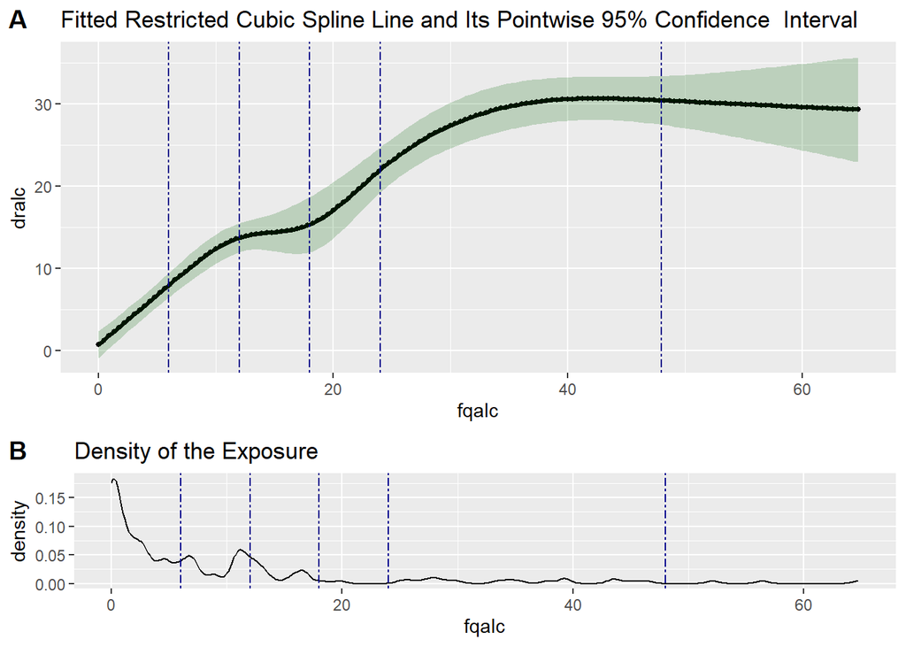

```r
# Plot spline
test6$fittedCBSplineCurve
```

Testing the linearity of between the `drcalinc` and `fqcalinc`.

```r
# Test if the calibration model is linear for variable calories intake
test5 <- testLinear(ds = valid_data,
                    outcome = "drcal", #"dralc", "drtfat"
                    var = "fqcal",
                    adj = c("fqtfat", "fqalc", "agec"),
                    nknots = 5,
                    method = "lm",
                    densplot = TRUE)
test5$testOfLinearity
```

```
##                                                         LRT-based chisq df
## Test of non-linear cubic spline terms                          1.728298  3
## Test of overall curvature (i.e. all cubic spline terms)        9.480342  4
## Test of linear term only.                                      7.752044  1
##                                                         p value
## Test of non-linear cubic spline terms                    0.6307
## Test of overall curvature (i.e. all cubic spline terms)  0.0502
## Test of linear term only.                                0.0054
```

No sufficient statistical evidence for non-linearity between mismeasured total calorie intake and validated total calorie intake.

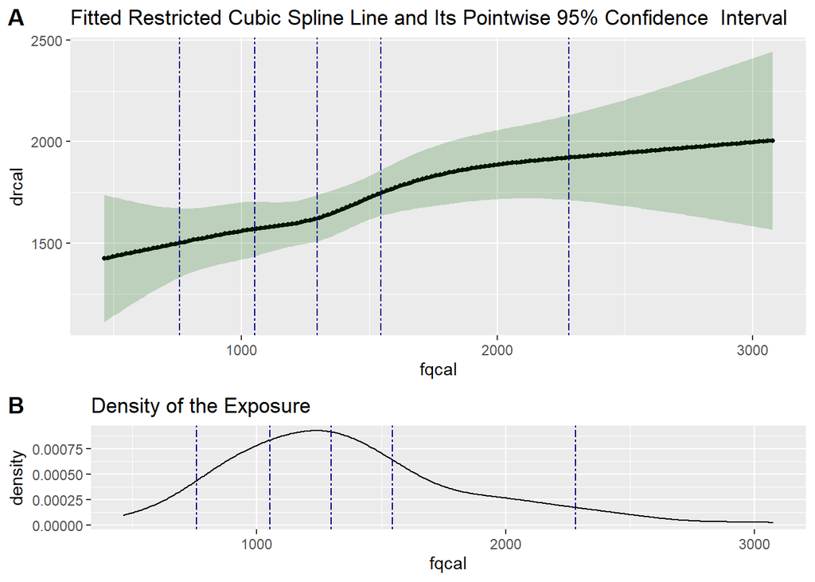

```r
# Plot spline
test5$fittedCBSplineCurve
```

**Exercise:** Testing the linearity between `drtfatinc` and `fqtfatinc`.

```r
# Test if the calibration model is linear for total fat intake
test4<-testLinear(ds=valid_data,
outcome ="drtfat", #"drcal", #"dralc", "drtfat"
var="fqtfat",
adj=c("fqcal","fqalc","agec"),
nknots=5,
method="lm",
densplot=TRUE)
test4$testOfLinearity
```

```
##                                                         LRT-based chisq df
## Test of non-linear cubic spline terms                          1.989486  3
## Test of overall curvature (i.e. all cubic spline terms)        9.879113  4
## Test of linear term only.                                      7.889627  1
##                                                         p value
## Test of non-linear cubic spline terms                    0.5746
## Test of overall curvature (i.e. all cubic spline terms)  0.0425
## Test of linear term only.                                0.0050
```

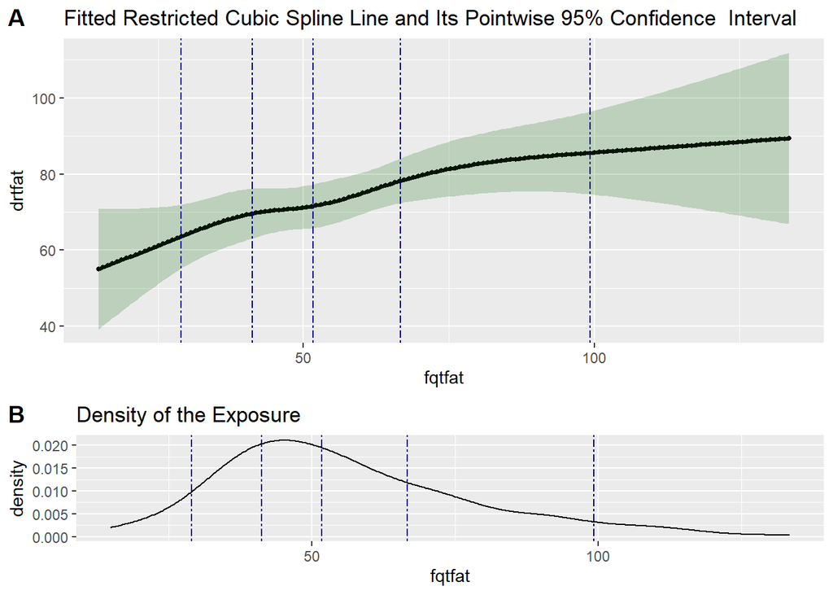

```r
# Plot spline
test4$fittedCBSplineCurve
```

### 1.8 RC-IM with Nonlinear Measurement Error Model

Consider the nonlinear terms of *FFQ_Alcohol(12g/day)* in the measurement error models:
$$\begin{aligned}
\mathrm{DR\_Alcohol}(12g/day)
&= \mathrm{FFQ\_Alcohol}(12g/day)
+ \mathrm{FFQ\_Total\_Fat}(10g/day)
+ \mathrm{FFQ\_Calories}(800kcal/day) \\
&\quad + \mathbf{1}\!\left(\mathrm{Age}\in[40,45)\right)
+ \mathbf{1}\!\left(\mathrm{Age}\in[45,50)\right)
+ \mathbf{1}\!\left(\mathrm{Age}\in[50,55)\right)
+ \mathbf{1}\!\left(\mathrm{Age}\ge 50\right)\\
&\quad +\text{Spline Terms for FFQ_Alcohol}(12g/day), \\[6pt]
\mathrm{DR\_Total\_Fat}(10g/day)
&= \mathrm{FFQ\_Total\_Fat}(10g/day)
+ \mathrm{FFQ\_Alcohol}(12g/day)
+ \mathrm{FFQ\_Calories}(800kcal/day) \\
&\quad + \mathbf{1}\!\left(\mathrm{Age}\in[40,45)\right)
+ \mathbf{1}\!\left(\mathrm{Age}\in[45,50)\right)
+ \mathbf{1}\!\left(\mathrm{Age}\in[50,55)\right)
+ \mathbf{1}\!\left(\mathrm{Age}\ge 50\right)\\
&\quad +\text{Spline Terms for FFQ_Alcohol}(10g/day), \\[6pt]
\mathrm{DR\_Calories}(800kcal/day)
&= \mathrm{FFQ\_Calories}(800kcal/day)
+ \mathrm{FFQ\_Alcohol}(12g/day)
+ \mathrm{FFQ\_Total\_Fat}(10g/day) \\
&\quad + \mathbf{1}\!\left(\mathrm{Age}\in[40,45)\right)
+ \mathbf{1}\!\left(\mathrm{Age}\in[45,50)\right)
+ \mathbf{1}\!\left(\mathrm{Age}\in[50,55)\right)
+ \mathbf{1}\!\left(\mathrm{Age}\ge 50\right)\\
&\quad +\text{Spline Terms for FFQ_Alcohol}(800kcal/day).
\end{aligned}$$

```r
library(dplyr)
```

Generate spline terms for *FFQ_Alcohol* for main data and validation data.

```r
library(Hmisc)
# Data preparation - create spline terms for alcohol
rcsalcList <- paste0("rcsfqalc.", seq(1,3))
# Include spline terms for every 12 g/day increment in alcohol in both MS and VS
rcsfqalc.main <- rcspline.eval(main_data$fqalcinc, knots=c(0.5,1,1.5,2,4))
colnames(rcsfqalc.main) <- rcsalcList
main1 <- cbind(main_data, rcsfqalc.main) %>% as.data.frame()
head(main1)
```

```
##       id fqcal fqcalinc fqtfat fqtfatinc  fqalc  fqalcinc      age  agec case
## 1 100008  1661  2.07625     88       8.8  8.413 0.7010833 48.75000 45~50    0
## 2 100013  1573  1.96625     65       6.5  0.000 0.0000000 37.83333   <40    0
## 3 100015  1071  1.33875     44       4.4  7.549 0.6290833 45.66667 45~50    0
## 4 100017  1000  1.25000     52       5.2 29.114 2.4261667 48.08333 45~50    0
## 5 100018  2013  2.51625     79       7.9 11.137 0.9280833 54.91667 50~55    0
## 6 100022  3073  3.84125    133      13.3  0.000 0.0000000 52.50000 50~55    0
##     rcsfqalc.1 rcsfqalc.2 rcsfqalc.3
## 1 0.0006637311  0.0000000 0.00000000
## 2 0.0000000000  0.0000000 0.00000000
## 3 0.0001755798  0.0000000 0.00000000
## 4 0.5723148133  0.2273187 0.05695528
## 5 0.0064039638  0.0000000 0.00000000
## 6 0.0000000000  0.0000000 0.00000000
```

```r
rcsfqalc <- rcspline.eval(valid_data$fqalcinc, knots=c(0.5,1,1.5,2,4))
colnames(rcsfqalc) <- rcsalcList
valid1 <- cbind(valid_data, rcsfqalc) %>% as.data.frame()
head(valid1)
```

```
##       id  fqcal fqcalinc fqtfat fqtfatinc fqalc  fqalcinc drcal drcalinc drtfat
## 1 100396 1242.2 1.552750   53.8      5.38  1.68 0.1400000  1807  2.25875  81.15
## 2 100566  907.0 1.133750   36.6      3.66  0.00 0.0000000  1418  1.77250  53.28
## 3 107633  786.0 0.982500   47.2      4.72 15.10 1.2583333  1889  2.36125  83.48
## 4 107737 1392.5 1.740625   55.3      5.53  7.49 0.6241667  1426  1.78250  49.65
## 5 107744 1259.8 1.574750   71.0      7.10 12.84 1.0700000  1253  1.56625  55.18
## 6 107813  987.1 1.233875   41.1      4.11  0.00 0.0000000  1699  2.12375  73.83
##   drtfatinc dralc   dralcinc age  agec   rcsfqalc.1 rcsfqalc.2 rcsfqalc.3
## 1     8.115  8.26 0.68833333  39   <40 0.0000000000 0.00000000          0
## 2     5.328  0.83 0.06916667  49 45~50 0.0000000000 0.00000000          0
## 3     8.348 20.13 1.67750000  43 40~45 0.0355995370 0.00140736          0
## 4     4.965 11.16 0.93000000  51 50~55 0.0001562712 0.00000000          0
## 5     5.518  7.18 0.59833333  53 50~55 0.0151177959 0.00002800          0
## 6     7.383  1.76 0.14666667  54 50~55 0.0000000000 0.00000000          0
```

Using substitution method (RegCalibSub) to correct measurement error where nonlinear terms for *FFQ_Alcohol* are considered in the measurement error models.

```r
rcim_nl <- RegCalibSub(ms = main1,  # MS
vs = valid1,                        # VS
sur = c("fqtfatinc","fqcalinc","fqalcinc"),
exp = c("drtfatinc","drcalinc","dralcinc"),
covCalib = c("agec", "rcsfqalc.1", "rcsfqalc.2", "rcsfqalc.3"),
# error-free covariates to adjust for in calibration model
# spline terms adjusted in the ME models included here
covOutcome = c("agec"),
# error-free covariates to adjust for in outcome model
# including non-linear terms.
outcome = "case",
method = "glm",    # methods for outcome modeling
family = binomial, # family parameter being passed to glm
link = "logit",    # link function being passed to glm
external = TRUE    # Indicates whether `vs` is an external validation set.
)
```

```r
# Print out results on OR scale
imputed_nl_results <- exp(cbind(OR = rcim_nl$correctedCoefTable[,1],
'2.5 %' = rcim_nl$correctedCoefTable[,5],
'97.5 %' = rcim_nl$correctedCoefTable[,6]))
imputed_nl_results
```

```
##                  OR     2.5 %   97.5 %
## drtfatinc 0.9563098 0.8167041 1.119780
## drcalinc  0.8926449 0.4081801 1.952116
## dralcinc  1.2724962 1.1108320 1.457688
## agec40~45 1.4072803 1.0267658 1.928812
## agec45~50 2.1403372 1.5798939 2.899589
## agec50~55 2.1481155 1.5888575 2.904225
## agec>=50  2.5185785 1.8617589 3.407121
```

Compare results from naive, deattenuation, substitution methods and substitution method with nonlinear measurement error model:

```r
Comparison_df <- as.data.frame(round(cbind(uncorrected_results[-1,], corrected_RC_DF, corrected_RC_IM, imputed_nl_results), 2))
Comparison_df
```

```
##             OR 2.5 % 97.5 %   OR 2.5 % 97.5 %   OR 2.5 % 97.5 %   OR 2.5 %
## fqtfatinc 0.98  0.92   1.04 0.93  0.79   1.10 0.93  0.80   1.09 0.96  0.82
## fqcalinc  1.00  0.77   1.29 1.01  0.45   2.24 1.01  0.46   2.22 0.89  0.41
## fqalcinc  1.15  1.06   1.23 1.24  1.08   1.44 1.24  1.08   1.43 1.27  1.11
## agec40~45 1.42  1.04   1.94 1.43  1.04   1.96 1.43  1.04   1.96 1.41  1.03
## agec45~50 2.29  1.73   3.05 2.14  1.57   2.92 2.14  1.57   2.92 2.14  1.58
## agec50~55 2.25  1.70   3.01 2.14  1.57   2.91 2.14  1.58   2.89 2.15  1.59
## agec>=50  2.66  2.00   3.56 2.54  1.86   3.46 2.54  1.87   3.44 2.52  1.86
##           97.5 %
## fqtfatinc   1.12
## fqcalinc    1.95
## fqalcinc    1.46
## agec40~45   1.93
## agec45~50   2.90
## agec50~55   2.90
## agec>=50    3.41
```

### Exercise

If only total fat intake (`fqtfatinc`) is measured with error, whereas total calorie intake and alcohol intake (`fqcalinc` and `fqalcinc`) are measured accurately, how should the code for the substitution method be modified when the measurement error model is nonlinear in alcohol?

```r
# put your code here

rcim_nl_fat <- RegCalibSub(ms = main1,  # MS
vs = valid1,                        # VS
sur = c("fqtfatinc"),
exp = c("drtfatinc"),
covCalib = c("fqcalinc","fqalcinc","agec", "rcsfqalc.1", "rcsfqalc.2", "rcsfqalc.3"),
# error-free covariates to adjust for in calibration model
# spline terms adjusted in the ME models included here
covOutcome = c("fqcalinc","fqalcinc","agec"),
# error-free covariates to adjust for in outcome model
# including non-linear terms.
outcome = "case",
method = "glm",    # methods for outcome modeling
family = binomial, # family parameter being passed to glm
link = "logit",    # link function being passed to glm
external = TRUE    # Indicates whether `vs` is an external validation set.
)

# Print out results on OR scale
imputed_nl_results_fat <- exp(cbind(OR = rcim_nl_fat$correctedCoefTable[,1],
'2.5 %' = rcim_nl_fat$correctedCoefTable[,5],
'97.5 %' = rcim_nl_fat$correctedCoefTable[,6]))
imputed_nl_results_fat
```

```
##                  OR     2.5 %   97.5 %
## drtfatinc 0.8875925 0.7644962 1.030509
## fqcalinc  1.0325600 0.8553453 1.246491
## fqalcinc  1.1663650 1.0799792 1.259661
## agec40~45 1.3967298 1.0139024 1.924104
## agec45~50 2.0346829 1.4819991 2.793480
## agec50~55 2.0520436 1.4946557 2.817293
## agec>=50  2.4313292 1.7731816 3.333760
```

## 2. Reliability Study Available

The R package **RegCalReliab** addresses measurement error in covariates when either an internal or an external reliability study is available. More details of the usage of the package are [here](https://lbw080526.github.io/RegCalReliab/articles/regcal_example.html).

## 3. Other Packages on Regression Calibration

The R package **mecor** implements regression calibration for linear model with continuous outcomes. More details of the usage of the package can be find [here](https://cran.r-project.org/web/packages/mecor/refman/mecor.html).